# Solutions for 07. Simple linear regression: categorical predictor

Notes and in-class exercises

```r
# Load packages and import data
library(ggplot2)
library(dplyr)

data(diamonds)

# A little bit of data wrangling code - let's not focus on this for now
diamonds <- diamonds %>%
    mutate(
        cut = factor(cut, ordered = FALSE),
        color = factor(color, ordered = FALSE),
        clarity = factor(clarity, ordered = FALSE)
    )
```

## Exercise 1: Get to know the data

- A case represents a single diamond.
- The distribution of price is right skewed with considerable high outliers. The right skew is evidenced by the mean price ($3932) being much higher than the median price ($2401).
- Most diamonds in this data are of Good cut or better. Ideal cut diamonds are the most common with each succesive grade being the next most common.

```r
dim(diamonds)
```

```
[1] 53940    10
```

```r
head(diamonds)
```

```
# A tibble: 6 × 10
  carat cut       color clarity depth table price     x     y     z
  <dbl> <fct>     <fct> <fct>   <dbl> <dbl> <int> <dbl> <dbl> <dbl>
1  0.23 Ideal     E     SI2      61.5    55   326  3.95  3.98  2.43
2  0.21 Premium   E     SI1      59.8    61   326  3.89  3.84  2.31
3  0.23 Good      E     VS1      56.9    65   327  4.05  4.07  2.31
4  0.29 Premium   I     VS2      62.4    58   334  4.2   4.23  2.63
5  0.31 Good      J     SI2      63.3    58   335  4.34  4.35  2.75
6  0.24 Very Good J     VVS2     62.8    57   336  3.94  3.96  2.48
```

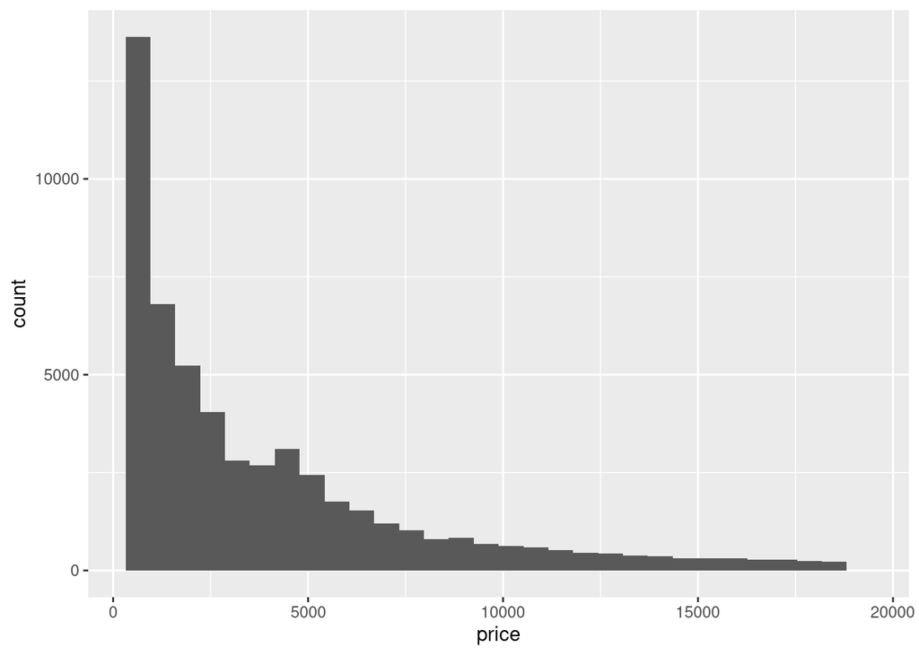

```r
# Visualize price (outcome variable)
ggplot(diamonds, aes(x = price)) +
    geom_histogram()
```

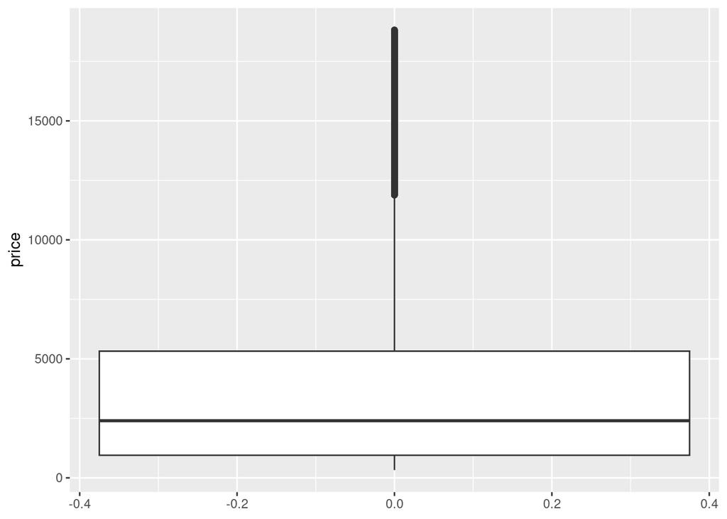

```r
ggplot(diamonds, aes(y = price)) +
    geom_boxplot()
```

```r
diamonds %>%
    summarize(mean(price), median(price), sd(price))
```

```
# A tibble: 1 × 3
  `mean(price)` `median(price)` `sd(price)`
          <dbl>           <dbl>       <dbl>
1         3933.            2401       3989.
```

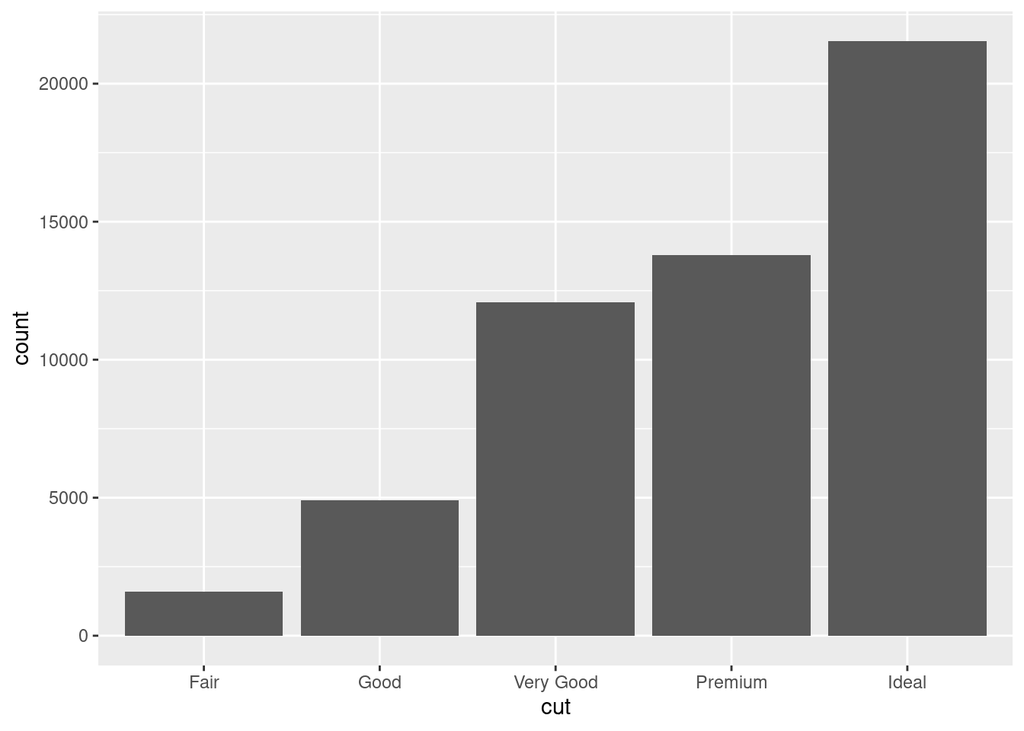

```r
# Visualize cut (predictor variable)
ggplot(diamonds, aes(x = cut)) +
    geom_bar()
```

```r
diamonds %>%
    count(cut)
```

```
# A tibble: 5 × 2
  cut           n
  <fct>     <int>
1 Fair       1610
2 Good       4906
3 Very Good 12082
4 Premium   13791
5 Ideal     21551
```

## Exercise 2: Visualizations

Start by visualizing this relationship of interest, that between `price` and `cut`.

1. We just don’t see anything clearly on a scatterplot. With the small number of unique values of the predictor variable, all of the points are bunched up on each other.

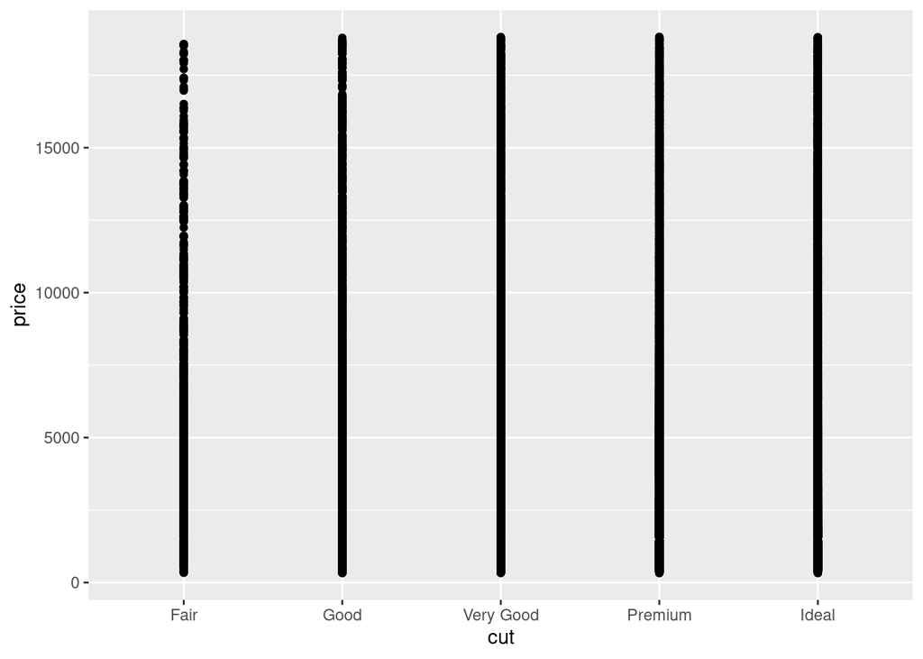

```r
# Try a scatterplot
ggplot(diamonds, aes(y = price, x = cut)) +
    geom_point()
```

2. Separately run each chunk below, with two plots. Comment (`#`) on what changes in the code / output.

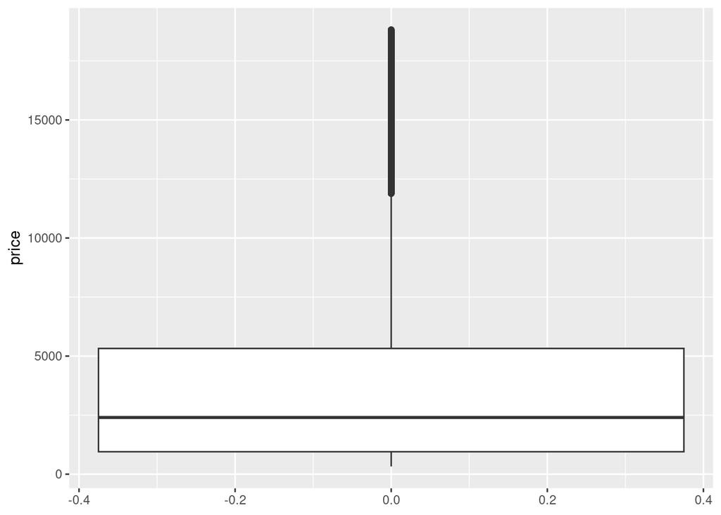

```r
# Univariate boxplot
ggplot(diamonds, aes(y = price)) +
    geom_boxplot()
```

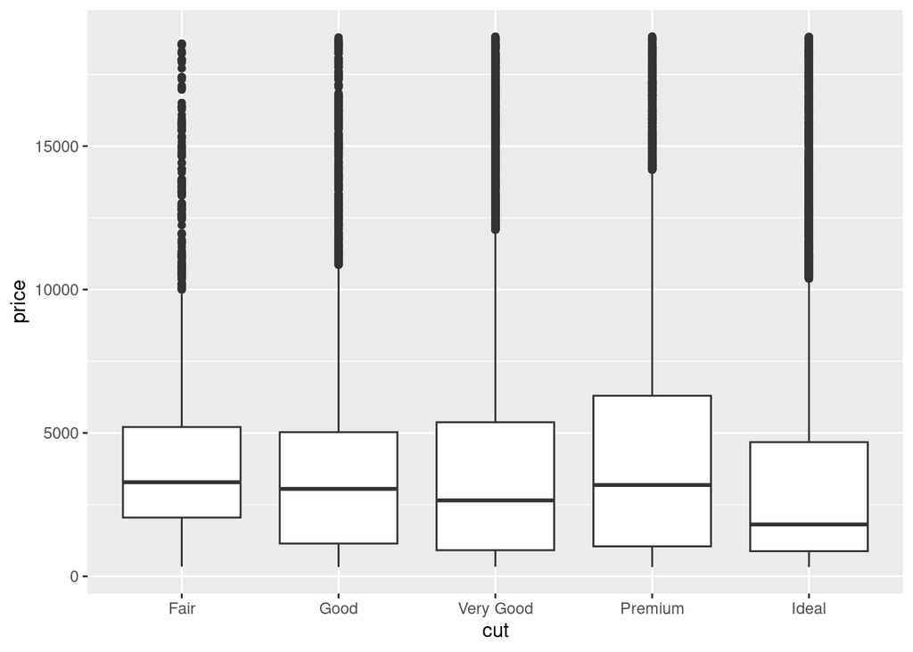

```r
# Separate boxes by category
ggplot(diamonds, aes(y = price, x = cut)) +
    geom_boxplot()
```

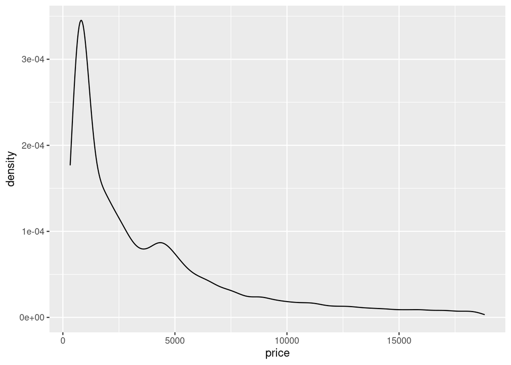

```r
# Univariate density plot
ggplot(diamonds, aes(x = price)) +
    geom_density()
```

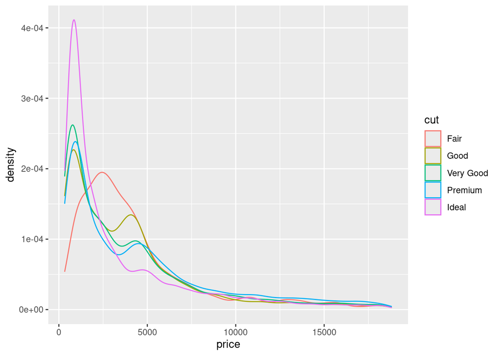

```r
# Separate density plots by category
ggplot(diamonds, aes(x = price, color = cut)) +
    geom_density()
```

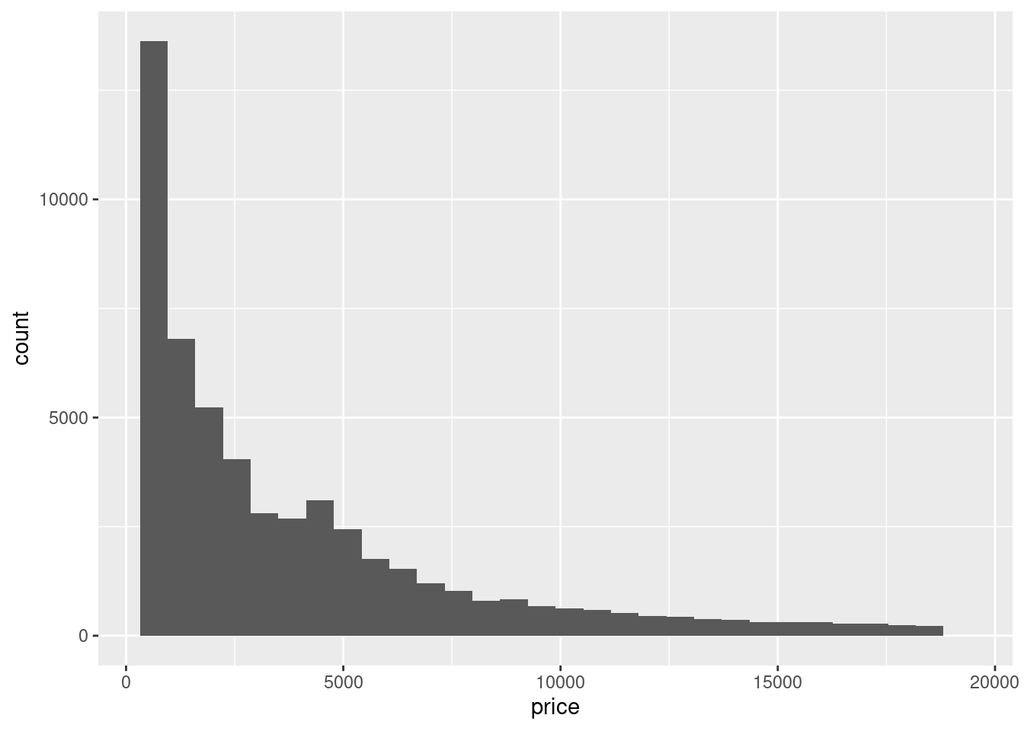

```r
# Univariate histogram
ggplot(diamonds, aes(x = price)) +
    geom_histogram()
```

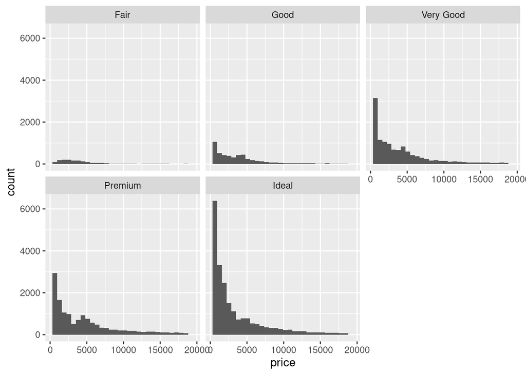

```r
# Separate histograms by category
ggplot(diamonds, aes(x = price)) +
    geom_histogram() +
    facet_wrap(~ cut)
```

## Exercise 3: Numerical summaries

Let’s follow up our plots with some numerical summaries.

1. Mean `price` across all diamonds:

```r
diamonds %>%
    summarize(mean(price))
```

```
# A tibble: 1 × 1
  `mean(price)`
          <dbl>
1         3933.
```

2. Mean `price` for each type of `cut`:

```r
diamonds %>%
    group_by(cut) %>%
    summarize(mean(price))
```

```
# A tibble: 5 × 2
  cut       `mean(price)`
  <fct>             <dbl>
1 Fair              4359.
2 Good              3929.
3 Very Good         3982.
4 Premium           4584.
5 Ideal             3458.
```

3. Group means should reflect what you see in the plots (easiest to see in the boxplots)
4. Create our new `cutFair` variable:

```r
diamonds <- diamonds %>%
  mutate(cutFair=ifelse(cut == "Fair", 1, 0))
```

5. Calculate the group means based on this new variable

```r
diamonds %>%
    group_by(cutFair) %>%
    summarize(mean(price))
```

```
# A tibble: 2 × 2
  cutFair `mean(price)`
    <dbl>         <dbl>
1       0         3920.
2       1         4359.
```

## Exercise 4: Modeling trend using a categorical predictor with exactly 2 categories

```r
# Construct the model
diamond_mod0 <- lm(price ~ cutFair, data = diamonds)

# Summarize the model
coef(summary(diamond_mod0))
```

```
             Estimate Std. Error    t value     Pr(>|t|)
(Intercept) 3919.6946    17.4367 224.795616 0.000000e+00
cutFair      439.0632   100.9269   4.350309 1.361951e-05
```

The intercept is the expected value (mean) of the price for all diamonds with a cut quality that isn’t Fair (Good, Very Good, Premium, or Ideal, i.e. when `cutFair` = 0)–the same as we saw in exercise 3e.

3. When we add the intercept and coefficient for `cutFair`, we get `3919.69 + 439.06 = 4358.75`–this is the mean price for all diamonds with a Fair cut quality that we saw in exercise 3e! Therefore, the coefficient of `cutFair` (439.06) is interpreted as the difference between the mean value of diamonds with a Fair cut quality and the mean value of diamonds with a higher cut quality.

## Exercise 5: Modeling trend using a categorical predictor with >2 categories

```r
# Construct the model
diamond_mod <- lm(price ~ cut, data = diamonds)

# Summarize the model
coef(summary(diamond_mod))
```

```
              Estimate Std. Error   t value     Pr(>|t|)
(Intercept)  4358.7578   98.78795 44.122361 0.000000e+00
cutGood      -429.8933  113.84940 -3.775982 1.595493e-04
cutVery Good -376.9979  105.16422 -3.584849 3.375707e-04
cutPremium    225.4999  104.39521  2.160060 3.077240e-02
cutIdeal     -901.2158  102.41155 -8.799943 1.408406e-18
```

1. We are seeing 4 coefficient estimates because each category is being assigned to a separate indicator variable–`cutGood` = 1 when `cut == "Good"` and 0 otherwise, `cutVery Good` = 1 when `cut == “Very Good” and 0 otherwise, and so on.
2. E[price | cut] = 4358.7578 - 429.8933 cutGood - 376.9979 cutVery Good + 225.4999 cutPremium - 901.2158 cutIdeal

## Exercise 6: Making sense of the model

1. Expected/typical price for diamonds of *Good* cut:

E[price | cut] = 4358.7578 - 429.8933 * 1 - 376.9979 * 0 + 225.4999 * 0 - 901.2158 * 0 = 4358.7578 - 429.8933 = $3928.865

```r
predict(diamond_mod, newdata = data.frame(cut = "Good"))
```

```
       1
3928.864
```

2. Expected/typical price for diamonds of *Fair* cut:

E[price | cut] = 4358.7578 - 429.8933 * 0 - 376.9979 * 0 + 225.4999 * 0 - 901.2158 * 0 = $4358.7578

```r
predict(diamond_mod, newdata = data.frame(cut = "Fair"))
```

```
       1
4358.758
```

3. These come from our group mean calculations in Exercise 3b! The predicted value for diamonds of *Fair* cut is also the same as what we obtained using the SLR model in exercise 4 with only a single `cutFair` indicator variable.

## Exercise 7: Interpreting coefficients

Recall that our model formula is *not a formula for a line*. Thus we can’t interpret the coefficients as “slopes” as we have before. Taking this into account and reflecting upon your calculations above…

1. The average price of a Fair cut diamonds is $4358.7578.
2. - Interpretation of `cutGood` coefficient: On average, Good cut diamonds are worth $429.89 less than Fair cut diamonds.
   - Interpretation of `cutVery Good` coefficient: On average, Very Good cut diamonds are worth $377.00 less than Fair cut diamonds.

## Exercise 8: Modeling choices (CHALLENGE)

Why do we fit this model in this way (using 4 indicator variables `cutGood`, `cutVery Good`, `cutPremium`, `cutIdeal`)? Instead, suppose that we created a single variable `cutCat` that gave each category a numerical value: 0 for Fair, 1 for Good, 2 for Very Good, 3 for Premium, and 4 for Ideal.

- If we used 0-4 instead of creating indicator variables, we would be constraining the change from 0 to 1, from 1 to 2, etc. to always be of the same magnitude. That is, a 1 unit change in the cut variable would always have the same change in price in our model.
- Using separate indicator variables allows the difference between subsequent categories to be different, which allows our model to be a bit more nuanced. It is possible to take nuance too far though. For example, in our previous investigations of bikeshare data, we modeled ridership versus temperature. We treated temperature as a quantitative predictor. Imagine if we had created an indicator variable for each unique temperature in the data—that would be so many variables! Having so many variables creates a very complex model which can be hard to make sense of. (These ideas are addressed further in STAT 253: Statistical Machine Learning!)

## Exercise 9: Diamond color

Consider modeling `price` by `color`.

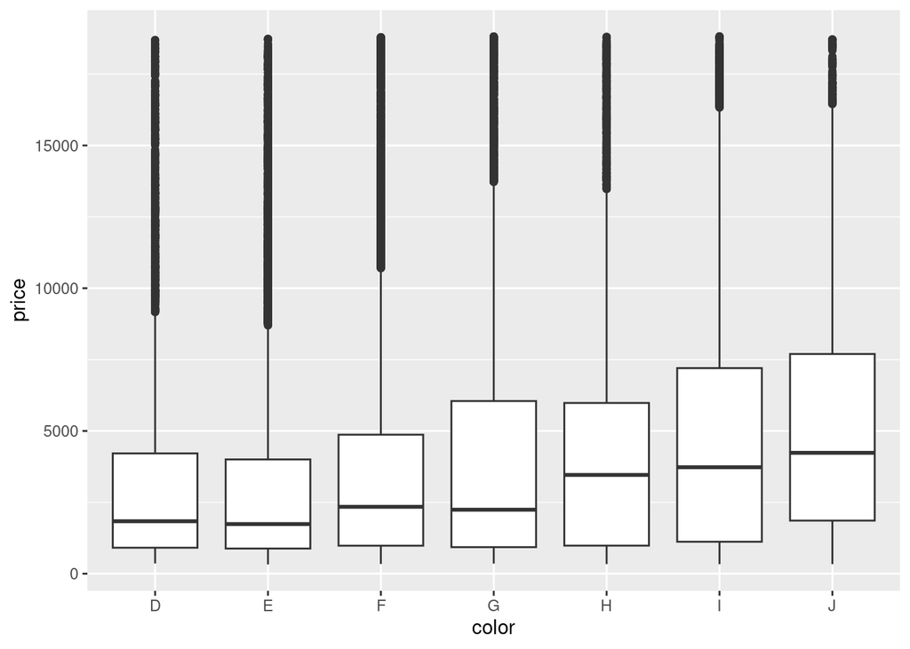

```r
ggplot(diamonds, aes(x = color, y = price)) +
    geom_boxplot()
```

```r
diamonds %>%
    group_by(color) %>%
    summarize(mean(price))
```

```
# A tibble: 7 × 2
  color `mean(price)`
  <fct>         <dbl>
1 D             3170.
2 E             3077.
3 F             3725.
4 G             3999.
5 H             4487.
6 I             5092.
7 J             5324.
```

- We fit a linear model and obtain the model formula: E[price | color] = 3169.95 - 93.20 colorE + 554.93 colorF + 829.18 colorG + 1316.72 colorH + 1921.92 colorI + 2153.86 colorJ

```r
diamond_mod2 <- lm(price ~ color, data = diamonds)

coef(summary(diamond_mod2))
```

```
              Estimate Std. Error   t value      Pr(>|t|)
(Intercept) 3169.95410   47.70694 66.446391  0.000000e+00
colorE       -93.20162   62.04724 -1.502107  1.330752e-01
colorF       554.93230   62.38527  8.895246  6.004834e-19
colorG       829.18158   60.34470 13.740751  6.836340e-43
colorH      1316.71510   64.28715 20.481777  7.074714e-93
colorI      1921.92086   71.55308 26.860072 7.078041e-158
colorJ      2153.86392   88.13203 24.439060 3.414906e-131
```

- Color D is the reference level because we don’t see its indicator variable in the model output.
- Interpretation of the intercept: Diamonds with D color cost $3169.95 on average.
- Interpretation of the `colorE` coefficient: Diamonds with E color cost $93.20 **less** than D color diamonds on average.
- Interpretation of the `colorF` coefficient: Diamonds with F color cost $554.93 **more** than D color diamonds on average.

## Exercise 10: Diamond clarity

We see the unexpected result that diamonds of better clarity (VS1 and higher) have lower average prices. In fact the best clarity diamonds (VVS1 and IF) have the *lowest* average prices. What might be going on? What if the most clear diamonds were also quite small…

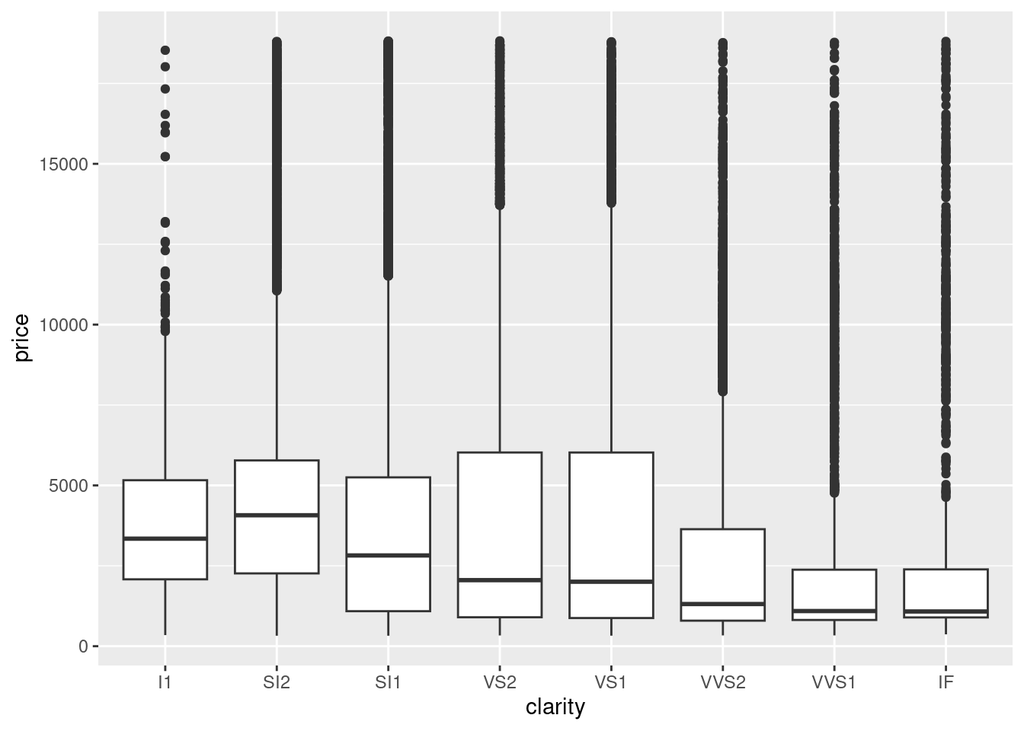

```r
ggplot(diamonds, aes(x = clarity, y = price)) +
    geom_boxplot()
```

```r
diamonds %>%
    group_by(clarity) %>%
    summarize(mean(price))
```

```
# A tibble: 8 × 2
  clarity `mean(price)`
  <fct>           <dbl>
1 I1              3924.
2 SI2             5063.
3 SI1             3996.
4 VS2             3925.
5 VS1             3839.
6 VVS2            3284.
7 VVS1            2523.
8 IF              2865.
```

```r
diamond_mod3 <- lm(price ~ clarity, data = diamonds)

coef(summary(diamond_mod3))
```

```
                 Estimate Std. Error      t value      Pr(>|t|)
(Intercept)  3924.1686910   144.5619 27.145247517 3.513547e-161
claritySI2   1138.8599147   150.2746  7.578526239  3.550711e-14
claritySI1     71.8324571   148.6049  0.483378837  6.288287e-01
clarityVS2      0.8207037   148.8672  0.005512992  9.956013e-01
clarityVS1    -84.7132999   150.9746 -0.561109670  5.747251e-01
clarityVVS2  -640.4316203   154.7737 -4.137858008  3.510944e-05
clarityVVS1 -1401.0540535   158.5401 -8.837224284  1.010097e-18
clarityIF   -1059.3295848   171.8990 -6.162510636  7.210567e-10
```